# Multi-Colinearity

Dr. Wayne Stewart

September 25, 2018

# Introduction

$$\hat{\beta}=(X^{'}X)^{-1}X^{'}Y$$

The point estimating solution requires $(X^{'}X)^{-1}$

To obtain interval estimates we also need the same thing – $(X^{'}X)^{-1}$

If one (or more) column(s) of the design matrix is/are a linear combination of the others then we can find a vector $a$ so that:

$$X_{n\times (k+1)}a_{(k+1)\times 1}=0,\;\; a\ne 0$$
This means the columns are colinear. In such a case

$$X^{'}(Xa)=0$$
Or:

$$(X^{'}X)a=0$$

Now, we can find a trivial solution to this if $(X^{'}X)^{-1}$ exists. That is $a=0$ – but this contracts our assumption that $a\ne 0$.

Hence $(X^{'}X)$ has no inverse when $Xa=0$ and $a\ne 0$ or put another way, if a column of $X$ is a linear combination of the other columns then the columns are colinear and $(X^{'}X)^{-1}$ does not exist and no interval or point $\hat{\beta}$ solutions can be created – at least with the linear model assumptions as we have them.

It is not however, likely that a column is the linear combination of the others. What is more likely is that a column might be nearly so i.e $Xa\approx 0$.

When this happens, estimates may be very unstable. The diagonal values of $(X^{'}X)^{-1}$ will often be large. This means that variability of the beta estimates is high.

# Detection

There are a number of methods. We will look at 4.

## Correlation

Make a pairs plot of the independent variables and seek the correlation between pairs. This is a bivariate relationship and it looks at only two variables at a time. A better way would be to look for how one variable relates to a linear combination of the others

## Non significant T tests

This is NOT proof but evidence consistent with MC. Individual $\beta$ parameters when the overal F adequacy test is significant

## Opposite signs

This is NOT proof but evidence consistent with MC. Opposite (from what is expected) signs of estimates.

## VIF = Variance Inflation Factors

We need a more multivariate approach and one that accesses the dependence of a variable on a linear combination of all the others.

$$Xa=0$$
$\newcommand{\myv}[2]{ \begin{pmatrix} #1_{1,#2}\\ #1_{2,#2}\\ \vdots\\ #1_{k,#2} \end{pmatrix} }$

$\newcommand{\mya}{ \begin{pmatrix} a_{1}\\ a_{2}\\ \vdots\\ a_{k} \end{pmatrix} }$

$\newcommand{\myone}{ \begin{pmatrix} 1\\ 1\\ \vdots\\ 1 \end{pmatrix} }$

Means:

$$X\mya=0$$

$$a_0\myone +a_1\myv{x}{1} + a_2\myv{x}{2}+\cdots + a_k\myv{x}{k}=0$$

Rearrange for one of the independent variables:

$$a_1\myv{x}{1} = -a_0\myone -a_2\myv{x}{2}-\cdots - a_k\myv{x}{k}$$

Now divide by $a_1$ and rewrite we have:

$$\myv{x}{1} = \zeta_0\myone + \zeta_1\myv{x}{2} +\cdots + \zeta_{k-1}\myv{x}{k}$$

Or in general:

$$\myv{x}{i}=\zeta_0\myone + \zeta_1\myv{x}{1}+\cdots + \zeta_{i-1}\myv{x}{i-1}+\zeta_i\myv{x}{i+1}+\cdots+\zeta_{k-1}\myv{x}{k}$$

This looks a lot like $y = \beta_0 +\beta_1 x_1 + \cdots + \beta_k x_k$

If we assume some sort of error structure on this we can obtain estimates for $x_i$ using least squares and then get a measure of $R_i^2$ to measure how much of a relationship $x_i$ has with the other independent variables.

The variance inflation factor is defined as:

$$VIF_i = \frac{1}{(1-R_i^2)}$$
If $VIF> 5$ then we likely have a measure of multicolinearity present.

# Solution

> 1. Drop a highly correlated variable by using stepwise regression – remove the parameter (and therefore the variable associated) with largest p value
> 2. Standardize variables (useful mainly in polynomial models)
> 3. Use ridge regression (constrain parameter estimates) $\hat{\beta}=(X^{'}X+kI)^{-1}X^{'}Y$
> 4. Use pca to make a new set of orthogonal variables

# Example

See MS pg 621

```r
ftc = myread("FTC2.xls")
head(ftc)
```

```
## # A tibble: 6 x 4
##     TAR NICOTINE WEIGHT    CO
##   <dbl>    <dbl>  <dbl> <dbl>
## 1  14.1     0.86  0.985  13.6
## 2  16       1.06  1.09   16.6
## 3  29.8     2.03  1.16   23.5
## 4   8       0.67  0.928  10.2
## 5   4.1     0.4   0.946   5.4
## 6  15       1.04  0.888  15
```

```r
y.lm  = lm(CO~.,data=ftc)
y.lm2 = lm(CO~TAR + NICOTINE,data=ftc)
y.lm3 = lm(CO~TAR,data=ftc)

x.lm = lm(TAR ~ NICOTINE + WEIGHT,data=ftc)

summary(y.lm)
```

```
##
## Call:
## lm(formula = CO ~ ., data = ftc)
##
## Residuals:
##      Min       1Q   Median       3Q      Max
## -2.89261 -0.78269  0.00428  0.92891  2.45082
##
## Coefficients:
##             Estimate Std. Error t value Pr(>|t|)
## (Intercept)   3.2022     3.4618   0.925 0.365464
## TAR           0.9626     0.2422   3.974 0.000692 ***
## NICOTINE     -2.6317     3.9006  -0.675 0.507234
## WEIGHT       -0.1305     3.8853  -0.034 0.973527
## ---
## Signif. codes:  0 '***' 0.001 '**' 0.01 '*' 0.05 '.' 0.1 ' ' 1
##
## Residual standard error: 1.446 on 21 degrees of freedom
## Multiple R-squared:  0.9186, Adjusted R-squared:  0.907
## F-statistic: 78.98 on 3 and 21 DF,  p-value: 1.329e-11
```

```r
summary(y.lm2)
```

```
##
## Call:
## lm(formula = CO ~ TAR + NICOTINE, data = ftc)
##
## Residuals:
##      Min       1Q   Median       3Q      Max
## -2.89941 -0.78470 -0.00144  0.91585  2.43064
##
## Coefficients:
##             Estimate Std. Error t value Pr(>|t|)
## (Intercept)   3.0896     0.8438   3.662 0.001371 **
## TAR           0.9625     0.2367   4.067 0.000512 ***
## NICOTINE     -2.6463     3.7872  -0.699 0.492035
## ---
## Signif. codes:  0 '***' 0.001 '**' 0.01 '*' 0.05 '.' 0.1 ' ' 1
##
## Residual standard error: 1.413 on 22 degrees of freedom
## Multiple R-squared:  0.9186, Adjusted R-squared:  0.9112
## F-statistic: 124.1 on 2 and 22 DF,  p-value: 1.042e-12
```

```r
summary(y.lm3)
```

```
##
## Call:
## lm(formula = CO ~ TAR, data = ftc)
##
## Residuals:
##     Min      1Q  Median      3Q     Max
## -3.1124 -0.7167 -0.3754  1.0091  2.5450
##
## Coefficients:
##             Estimate Std. Error t value Pr(>|t|)
## (Intercept)  2.74328    0.67521   4.063 0.000481 ***
## TAR          0.80098    0.05032  15.918 6.55e-14 ***
## ---
## Signif. codes:  0 '***' 0.001 '**' 0.01 '*' 0.05 '.' 0.1 ' ' 1
##
## Residual standard error: 1.397 on 23 degrees of freedom
## Multiple R-squared:  0.9168, Adjusted R-squared:  0.9132
## F-statistic: 253.4 on 1 and 23 DF,  p-value: 6.552e-14
```

```r
summary(x.lm)
```

```
##
## Call:
## lm(formula = TAR ~ NICOTINE + WEIGHT, data = ftc)
##
## Residuals:
##     Min      1Q  Median      3Q     Max
## -2.6065 -0.7612  0.1921  0.6349  2.5234
##
## Coefficients:
##             Estimate Std. Error t value Pr(>|t|)
## (Intercept)  -1.6500     3.0263  -0.545    0.591
## NICOTINE     15.6038     0.8472  18.419 7.39e-15 ***
## WEIGHT        0.1967     3.4193   0.058    0.955
## ---
## Signif. codes:  0 '***' 0.001 '**' 0.01 '*' 0.05 '.' 0.1 ' ' 1
##
## Residual standard error: 1.272 on 22 degrees of freedom
## Multiple R-squared:  0.9538, Adjusted R-squared:  0.9496
## F-statistic: 226.9 on 2 and 22 DF,  p-value: 2.062e-15
```

```r
library(car)
library(s20x)
vif(y.lm)
```

```
##       TAR  NICOTINE    WEIGHT
## 21.630706 21.899917  1.333859
```

```r
vif(y.lm2)
```

```
##      TAR NICOTINE
## 21.62745 21.62745
```

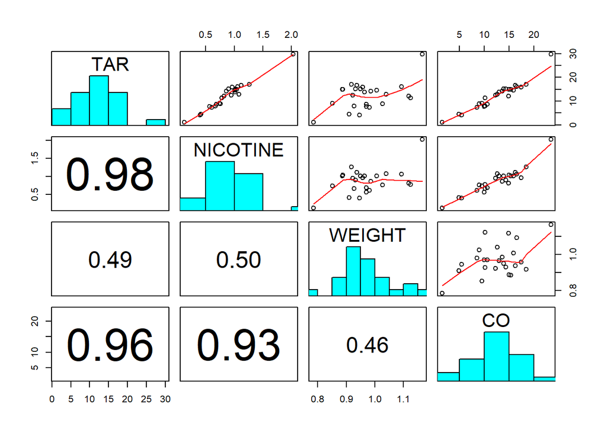

```r
pairs20x(ftc)
```

# Model selection methods in the presence of multicolinearity

## Forward

step(baseModel,scope=list(upper=fullModel,lower=~1),direction=“forward”)

We will look at using forward model selection with AIC as function we wish to minimize.

```r
null=lm(CO~1,data=ftc)
full = lm(CO~.^2,data=ftc)

step(null, scope=list(upper=full, lower=null),direction="forward")
```

```
## Start:  AIC=78.78
## CO ~ 1
##
##            Df Sum of Sq    RSS    AIC
## + TAR       1    494.28  44.87 18.622
## + NICOTINE  1    462.26  76.89 32.089
## + WEIGHT    1    116.06 423.09 74.718
## <none>                  539.15 78.778
##
## Step:  AIC=18.62
## CO ~ TAR
##
##            Df Sum of Sq    RSS    AIC
## <none>                  44.869 18.622
## + NICOTINE  1   0.97415 43.895 20.073
## + WEIGHT    1   0.02507 44.844 20.608
```

```
##
## Call:
## lm(formula = CO ~ TAR, data = ftc)
##
## Coefficients:
## (Intercept)          TAR
##       2.743        0.801
```

## Backward

Lets do the same this time with backward selection

```r
step(full,scope=list(upper= full,lower=null), direction="backward")
```

```
## Start:  AIC=15.07
## CO ~ (TAR + NICOTINE + WEIGHT)^2
##
##                   Df Sum of Sq    RSS    AIC
## - TAR:NICOTINE     1   0.16355 26.252 13.222
## - TAR:WEIGHT       1   0.92103 27.010 13.933
## - NICOTINE:WEIGHT  1   1.41969 27.508 14.390
## <none>                         26.089 15.066
##
## Step:  AIC=13.22
## CO ~ TAR + NICOTINE + WEIGHT + TAR:WEIGHT + NICOTINE:WEIGHT
##
##                   Df Sum of Sq    RSS    AIC
## - TAR:WEIGHT       1   0.85203 27.104 12.020
## - NICOTINE:WEIGHT  1   1.63269 27.885 12.730
## <none>                         26.252 13.222
##
## Step:  AIC=12.02
## CO ~ TAR + NICOTINE + WEIGHT + NICOTINE:WEIGHT
##
##                   Df Sum of Sq    RSS    AIC
## <none>                         27.104 12.020
## - NICOTINE:WEIGHT  1    16.788 43.893 22.072
## - TAR              1    29.790 56.895 28.558
```

```
##
## Call:
## lm(formula = CO ~ TAR + NICOTINE + WEIGHT + NICOTINE:WEIGHT,
##     data = ftc)
##
## Coefficients:
##     (Intercept)              TAR         NICOTINE           WEIGHT
##        -11.5032           0.9166          14.8637          14.5804
## NICOTINE:WEIGHT
##        -16.5724
```

## Both directions

```r
step(full,scope=list(upper= full,lower=null), direction="both")
```

```
## Start:  AIC=15.07
## CO ~ (TAR + NICOTINE + WEIGHT)^2
##
##                   Df Sum of Sq    RSS    AIC
## - TAR:NICOTINE     1   0.16355 26.252 13.222
## - TAR:WEIGHT       1   0.92103 27.010 13.933
## - NICOTINE:WEIGHT  1   1.41969 27.508 14.390
## <none>                         26.089 15.066
##
## Step:  AIC=13.22
## CO ~ TAR + NICOTINE + WEIGHT + TAR:WEIGHT + NICOTINE:WEIGHT
##
##                   Df Sum of Sq    RSS    AIC
## - TAR:WEIGHT       1   0.85203 27.104 12.020
## - NICOTINE:WEIGHT  1   1.63269 27.885 12.730
## <none>                         26.252 13.222
## + TAR:NICOTINE     1   0.16355 26.089 15.066
##
## Step:  AIC=12.02
## CO ~ TAR + NICOTINE + WEIGHT + NICOTINE:WEIGHT
##
##                   Df Sum of Sq    RSS    AIC
## <none>                         27.104 12.020
## + TAR:WEIGHT       1    0.8520 26.252 13.222
## + TAR:NICOTINE     1    0.0946 27.010 13.933
## - NICOTINE:WEIGHT  1   16.7883 43.893 22.072
## - TAR              1   29.7904 56.895 28.558
```

```
##
## Call:
## lm(formula = CO ~ TAR + NICOTINE + WEIGHT + NICOTINE:WEIGHT,
##     data = ftc)
##
## Coefficients:
##     (Intercept)              TAR         NICOTINE           WEIGHT
##        -11.5032           0.9166          14.8637          14.5804
## NICOTINE:WEIGHT
##        -16.5724
```

# Conclusion

The first thing you will need to do is take care of multicolinearity. Then use some step like procedure to select models.

In many cases this will mean deleting one of a pair of independent variables which are highly correlated (TAR or NICOTINE but not both!!). Then use a step procedure on the remaining data.

```r
nullr = lm(CO~1,data=ftc[,-1]) # remove TAR
fullr = lm(CO~.^2, data=ftc[,-1])
step(fullr,scope=list(upper= fullr,lower=nullr), direction="backward")
```

```
## Start:  AIC=28.56
## CO ~ (NICOTINE + WEIGHT)^2
##
##                   Df Sum of Sq    RSS    AIC
## <none>                         56.895 28.558
## - NICOTINE:WEIGHT  1    19.999 76.894 34.089
```

```
##
## Call:
## lm(formula = CO ~ (NICOTINE + WEIGHT)^2, data = ftc[, -1])
##
## Coefficients:
##     (Intercept)         NICOTINE           WEIGHT  NICOTINE:WEIGHT
##          -14.32            30.66            16.07           -18.05
```

```r
nullr2 = lm(CO~1,data=ftc[,-2]) # remove Nicotine
fullr2 = lm(CO~.^2, data=ftc[,-2])
step(fullr2,scope=list(upper= fullr2,lower=nullr2), direction="backward")
```

```
## Start:  AIC=10.96
## CO ~ (TAR + WEIGHT)^2
##
##              Df Sum of Sq    RSS    AIC
## <none>                    28.145 10.962
## - TAR:WEIGHT  1    16.699 44.844 20.608
```

```
##
## Call:
## lm(formula = CO ~ (TAR + WEIGHT)^2, data = ftc[, -2])
##
## Coefficients:
## (Intercept)          TAR       WEIGHT   TAR:WEIGHT
##     -10.320        1.884       13.220       -1.075
```